# UCI Real State Valuation

Diego Alejandro Alvarado Rivera

En el siguiente notebook se utiliza el “Real state valuation data set”. Este contiene información histórica de valuaciones inmobiliarias realizadas en Sindian District, New Taipei City, Taiwan en los años 2012 y 2013.

Extraído de https://archive.ics.uci.edu/ml/datasets/Real+estate+valuation+data+set

```r
library(mgcv)
library(ggplot2)
library(patchwork)
library(mgcViz)
library(dplyr)
library(kableExtra)
library(randomForest)
```

# Descripción de las variables

El siguiente dataset está compuesto de 414 observaciones y 7 atributos.

- **transaction_date**: fecha de la transacción (por ejemplo, 2013.250=2013 March, 2013.500=2013 June, etc.)
- **house_age**: antigüedad de la casa (años)
- **dist_MRT_station**: distancia a la estación MRT más cercana (metros)
- **numb_conv_stores**: número de tiendas de conveniencia cercanas (unidades)
- **latitude**: coordenada geográfica correspondiente a la latitud (grados)
- **longitude**: coordenada geográfica correspondiente a la longitud (grados)
- **price_of_unit_area**: precio de la casa por unidad de area (10000 dólares taiwaneses/Ping, 1 Ping: 3.3 metros cuadrados)

El objetivo es predecir el precio por unidad de área e identificar cómo las diferentes variables influyen en el precio.

```r
set.seed(0)
path <- "datasets/UCI real state valuation/Real_estate_valuation_dataset.csv"
data = read.csv(file=path)
#str(data)
```

Como primer paso se analiza la distribución de cada una de las variables para comprobar que no existan problemas con los datos.

Se puede observar que existe una observación cuyo precio por unidad de área es 120. Ya que este valor es un outlier se procede a eliminarlo.

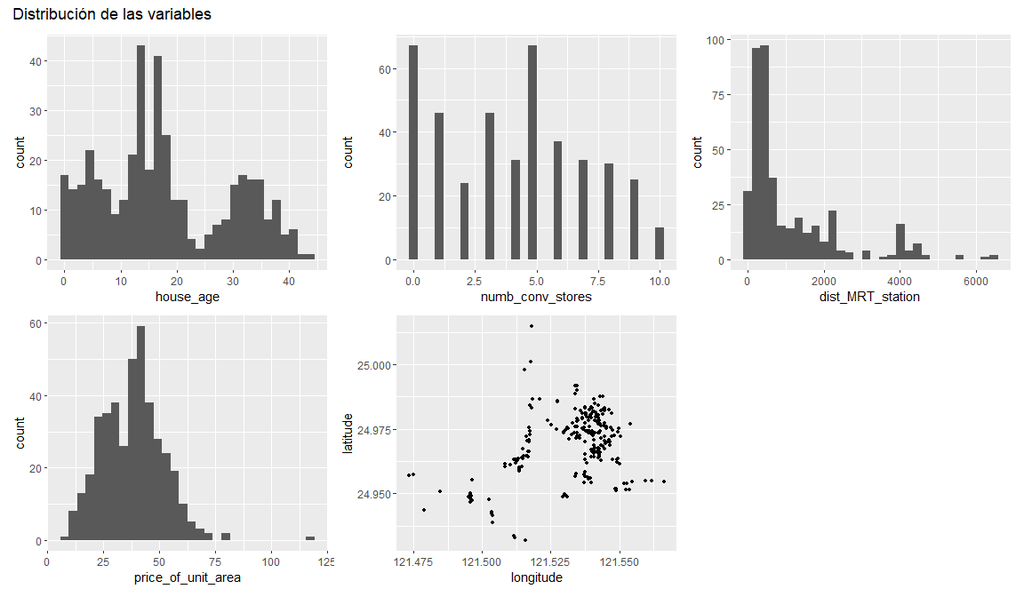

```r
p1 <- ggplot(data, aes(x=house_age)) + geom_histogram()
p2 <- ggplot(data, aes(x=numb_conv_stores)) + geom_histogram()
p3 <- ggplot(data, aes(x=dist_MRT_station)) + geom_histogram()
p4 <- ggplot(data, aes(x=price_of_unit_area)) + geom_histogram()
p5 <- ggplot(data, aes(x=longitude, y=latitude)) + geom_point(size=1)
p1 + p2 + p3 + p4 +  p5 +
  plot_annotation(title = "Distribución de las variables")
```

```r
# eliminar outliers
data <- data[data$price_of_unit_area <= 100, ]
```

# Separación del conjunto de datos en train y test

Se procede a separar el dataset en dos conjuntos

- train: este conjunto se utilizará para el entrenamiento los modelos y la optimización de hiperparámetros
- test: este conjunto se utilizará para evaluar el rendimiento de los modelos

El número de observaciones que corresponde a cada dataset es el siguiente:

- train: 289 obvs
- test: 124 obvs

```r
# Crear el conjunto de datos de entrenamiento
train_data = data %>% sample_frac(.70)
#Create test set
test_data  <- anti_join(data, train_data, by="ï..No")
#print(dim(train_data))
#print(dim(test_data))
```

# Exploración de los datos de entrenamiento

En esta etapa se realiza un analisis exploratorio de los datos para tratar de determinar las relaciones que existen entre las distintas variables de entrada y el precio.

En el siguiente gráfico se puede observar que la mayor presencia de tiendas de conveniencia tiene un efecto postivo en el precio. Lo contrario ocurre con a distancia a las estación MRT más cercana, ya que las casas más lejanas tienden a tener menores precios. Finalmente, la antigüedad de la casa parece influenciar de forma negativa.

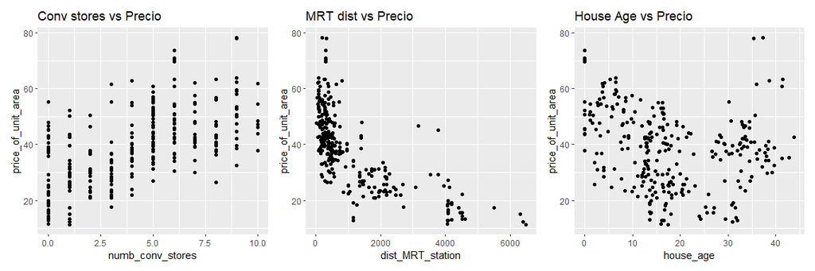

```r
p1 <- ggplot(train_data, aes(x=numb_conv_stores,
                             y=price_of_unit_area)) +
  geom_point()
p2 <- ggplot(train_data, aes(x=dist_MRT_station,
                             y=price_of_unit_area)) +
  geom_point()
p3 <- ggplot(train_data, aes(x=house_age,
                             y=price_of_unit_area)) +
  geom_point()
p1 + ggtitle("Conv stores vs Precio") +
  p2 + ggtitle("MRT dist vs Precio") +
  p3 + ggtitle("House Age vs Precio")
```

Posteriormente, se analiza el efecto de la localización geográfica en el precio. Aunque a primera vista las residencias en el noreste parecen tener precios superiores, se observa que estas propiedades tienden a estar más cerca a una estación MRT y disponen de mayor cantidad de tiendas de conveniencia en la cercanía (anteriormente se obsevó que estas variables se correlacionan con el precio).

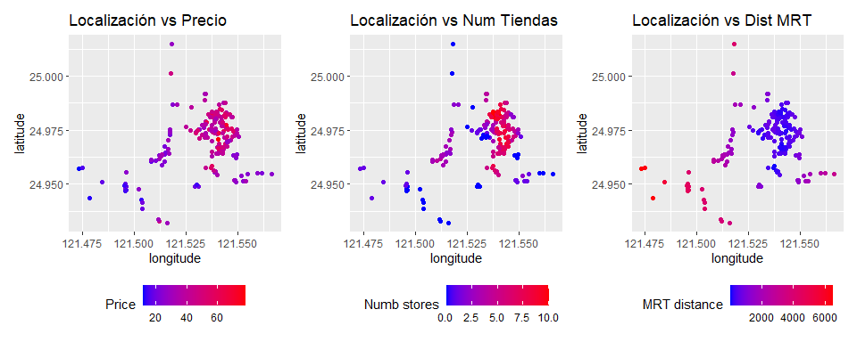

```r
p3 <- ggplot(train_data, aes(x=longitude, y=latitude, color=dist_MRT_station)) +
  geom_point() +
  scale_color_gradient(low="blue", high="red") +
  labs(fill = "asdfs") +
  labs(color="MRT distance") +
  theme(legend.position="bottom")

p2 <- ggplot(train_data, aes(x=longitude, y=latitude, color=numb_conv_stores)) +
  geom_point() +
  scale_color_gradient(low="blue", high="red") +
  labs(color="Numb stores") +
  theme(legend.position="bottom", legend.box = "vertical")
p1 <- ggplot(train_data, aes(x=longitude, y=latitude, color=price_of_unit_area)) +
  geom_point() +
  scale_color_gradient(low="blue", high="red") +
  labs(color="Price") +
  theme(legend.position="bottom", legend.box = "vertical")
p1 + ggtitle("Localización vs Precio") +
  p2+ggtitle("Localización vs Num Tiendas") +
  p3+ggtitle("Localización vs Dist MRT")
```

# Modelamiento

A continuación se procede a modelar el precio por unidad de área. Se evaluará tres modelos:

- **GAM sin localización geográfica** (GAM 1): house age, number of stores, MRT station distance
- **GAM con localización geográfica** (GAM 2): house age, latitude, longitude
- **Random Forests** (RF): todas las variables

Se considerará modelos GAMs ya que son flexibles, pero interpretables. Adicionalmente, se entrenará un modelo random forest para comparar el rendimiento de los modelos.

Ya que las GAM son modelos lineales, estas son sensibles a la concurvidad, la cual puede degradar severamente la estimación de los parámetros del modelo. Como se vio anteriormente, las variables “numb_conv_stores” y “dist_MRE_station” están fuertemente relacionadas con la localización geográfica. Así, estas variables no pueden ser utilizadas de forma conjunta en un mismo modelo.

### Entrenamiento del modelo GAM 1

**Detalles del modelo**:

- Se aplicará smooths a todas las variables de entrada y se inluirá un intercepto
- Los hiperparámetros se seleccionan automáticamente (minimizando el leave-one-out CV error)

**Validación de los supuestos del modelo:** (ver apéndice)

- Los errores se distribuyen aproximadamente de forma normal, aunque existen algunos errores positivos bastante grandes.
- El modelo converge y no se observan problemas de concurvidad

**Resultados del entrenamiento:**

- El modelo es altamente significativo (varianza explicada = 70.9%)
- Todas las variables incluidas tienen efectos significativos en el precio
- Leave-one-out CV error: 60.92

**REPORTE DEL MODELO GAM 1**

```r
# Entrenamiento del primer modelo
gam_mod <- gam(price_of_unit_area ~
                 s(house_age, k=10)+
                 s(dist_MRT_station, k=10) +
                 s(numb_conv_stores, k=10),
               data=train_data)
# mostrar los resultados del entenamiento
summary(gam_mod)
```

```
Family: gaussian
Link function: identity

Formula:
price_of_unit_area ~ s(house_age, k = 10) + s(dist_MRT_station,
    k = 10) + s(numb_conv_stores, k = 10)

Parametric coefficients:
            Estimate Std. Error t value Pr(>|t|)
(Intercept)   38.129      0.446    85.5   <2e-16 ***
---
Signif. codes:  0 ‘***’ 0.001 ‘**’ 0.01 ‘*’ 0.05 ‘.’ 0.1 ‘ ’ 1

Approximate significance of smooth terms:
                      edf Ref.df      F  p-value
s(house_age)        6.972  8.049  9.152  < 2e-16 ***
s(dist_MRT_station) 6.922  7.982 15.736  < 2e-16 ***
s(numb_conv_stores) 1.431  1.729 13.149 1.95e-05 ***
---
Signif. codes:  0 ‘***’ 0.001 ‘**’ 0.01 ‘*’ 0.05 ‘.’ 0.1 ‘ ’ 1

R-sq.(adj) =  0.693   Deviance explained = 70.9%
GCV =  60.92  Scale est. = 57.479    n = 289
```

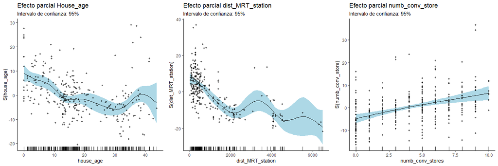

```r
b <- getViz(gam_mod)
gridPrint(plot(sm(b, 1)) + l_ciPoly(fill="lightblue", level=0.95) + l_fitLine() + l_rug(mapping = aes(x=x), alpha = 0.8) +
            l_points(shape = 19, size = 1, alpha = 0.5) + theme_classic() +
            ggtitle("Efecto parcial House_age", subtitle = "Intervalo de confianza: 95%") +  ylab("S(house_age)"),
          plot(sm(b, 2)) + l_ciPoly(fill="lightblue", level=0.95) + l_fitLine() + l_rug(mapping = aes(x=x), alpha = 0.8) +
            l_points(shape = 19, size = 1, alpha = 0.5) + theme_classic()+
            ggtitle("Efecto parcial dist_MRT_station", subtitle = "Intervalo de confianza: 95%")  +
            ylab("S(dist_MRT_station)"),
          plot(sm(b, 3)) + l_ciPoly(fill="lightblue", level=0.95) + l_fitLine() + l_rug(mapping = aes(x=x), alpha = 0.8) +
            l_points(shape = 19, size = 1, alpha = 0.5) + theme_classic()+
            ggtitle("Efecto parcial numb_conv_store", subtitle = "Intervalo de confianza: 95%") +
            ylab("S(numb_conv_store)"),
          ncol = 3)
```

### Entrenamiento del modelo GAM 2

**Detalles del modelo**:

- Se aplicará un smooth a house_age y se incluirá un intercepto
- Para capturar el efecto de la localización geofráfica, se utilizará un smooth de dos dimensiones (lat, long)
- los hiperparámetros se seleccionan automáticamente (minimizando el leave-one-out CV error)

**Validación de los supuestos del modelo:** (ver apéndice)

- Los errores se distribuyen aproximadamente de forma normal, aunque existen algunos errores positivos bastante grandes.
- El modelo converge y no se observan problemas de concurvidad

**Resultados del entrenamiento:**

- El modelo es altamente significativo (varianza explicada = 82.2%)
- Todas las variables incluidas tienen efectos significativos en el precio
- Leave-one-out CV error: 46.241

**REPORTE DEL MODELO GAM 2**

```r
# Entrenar el segundo modelo GAM
gam_mod_2 <- gam(price_of_unit_area ~ s(house_age)
                  + s(longitude, latitude, k=75),
               data=train_data)
# Mostrar los resultados
summary(gam_mod_2)
```

```
Family: gaussian
Link function: identity

Formula:
price_of_unit_area ~ s(house_age) + s(longitude, latitude, k = 75)

Parametric coefficients:
            Estimate Std. Error t value Pr(>|t|)
(Intercept)  38.1294     0.3681   103.6   <2e-16 ***
---
Signif. codes:  0 ‘***’ 0.001 ‘**’ 0.01 ‘*’ 0.05 ‘.’ 0.1 ‘ ’ 1

Approximate significance of smooth terms:
                         edf Ref.df     F p-value
s(house_age)           2.635  3.222 19.37  <2e-16 ***
s(longitude,latitude) 40.582 51.524 14.99  <2e-16 ***
---
Signif. codes:  0 ‘***’ 0.001 ‘**’ 0.01 ‘*’ 0.05 ‘.’ 0.1 ‘ ’ 1

R-sq.(adj) =  0.791   Deviance explained = 82.2%
GCV = 46.241  Scale est. = 39.166    n = 289
```

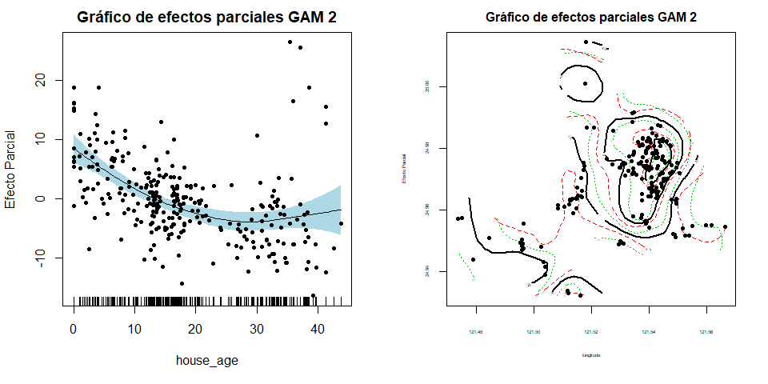

```r
# Plot the results
plot(gam_mod_2,
     #seWithMean = TRUE, shift = coef(gam_mod_2)[1],
     all.terms = TRUE, shade=TRUE, shade.col = "lightblue",
     residuals = TRUE, pch=20, pages=1,
     main="Gráfico de efectos parciales GAM 2",
     ylab="Efecto Parcial")
```

### Entrenamiento del modelo RF

**Detalles del modelo**:

- Se utilizó todas las varaibles de entrada.
- El modelo está compuesto por 750 árboles de decisión entrenados utilizando una muestra con reemplazo de tamaño 230 (80% del total de los datos).
- El tamano mínimo de nodo y el número de variables por partición se seleccionaron de tal manera que se minimice of Out-of-bag error.

**Resultados del entrenamiento:**

- Out-of-bag error (MSE): 43.36
- Varianza explicada: 76.73%

```r
set.seed(0)
RF = randomForest(price_of_unit_area~
                    house_age+
                    dist_MRT_station+
                    numb_conv_stores+
                    latitude+
                    longitude,
                  data=train_data,
                  ntree=750,
                  mtry=1,
                  nodesize=4,
                  replace=TRUE,
                  sampsize=230)
print(RF)
```

```
Call:
 randomForest(formula = price_of_unit_area ~ house_age + dist_MRT_station +      numb_conv_stores + latitude + longitude, data = train_data,      ntree = 750, mtry = 1, nodesize = 4, replace = TRUE, sampsize = 230)
               Type of random forest: regression
                     Number of trees: 750
No. of variables tried at each split: 1

          Mean of squared residuals: 43.36259
                    % Var explained: 76.73
```

# Evaluación de los modelos en test

Finalmente, se comparará los modelos utilizando el conjunto de datos de test. Esta es la prueba final a la que se someterán los modelos.

[output not shown]

Como se puede observar en la anterior tabla, el modelo RF obtiene los mejores resultados, seguido del modelo GAM 2.

Dependiendo de las necesidades del proyecto se seleccionará un modelo final. Si el objetivo en únicamente realizar buenas predicciones, entonces se preferirá el modelo RF. Sin embargo, si es necesario un modelo interpretable, entonces se seleccionará el modelo GAM 2. En este caso, se seleccionará el modelo GAM 2 y se interpretará sus resultados.

```r
y_test_pred_gam1 = predict(gam_mod, test_data)
y_test_pred_gam2 = predict(gam_mod_2, test_data)
y_test_pred_rf = predict(RF, test_data)
gam1_errors = test_data$price_of_unit_area - y_test_pred_gam1
gam2_errors = test_data$price_of_unit_area - y_test_pred_gam2
rf_errors = test_data$price_of_unit_area - y_test_pred_rf
print(mean((gam1_errors)**2)**0.5 )
print(mean((gam2_errors)**2)**0.5 )
print(mean((rf_errors)**2)**0.5 )
```

# Interpretación del modelo GAM 2

En el siguiente gráfico se observa el efecto parcial de las variables. En el primer gráfico se observa que las propiedades del sur tienden a sufrir una penalización negativa en el precio, mientras que en ciertas zonas del norte, obtienen bonficaciones positivas.

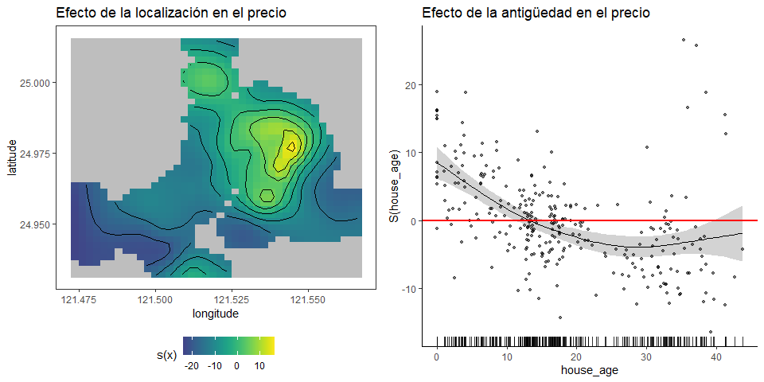

```r
b <- getViz(gam_mod_2)
gridPrint(plot(sm(b, 2)) + l_fitRaster() + l_fitContour() +
            labs(title = "Efecto de la localización en el precio")+ theme(legend.position="bottom", legend.box = "vertical"),
          plot(sm(b, 1)) + l_ciPoly() + l_fitLine() + l_rug(mapping = aes(x=x), alpha = 0.8) +
            l_points(shape = 19, size = 1, alpha = 0.5) + theme_classic() + labs(title="Efecto de la antigüedad en el precio") +
            ylab("S(house_age)") + geom_hline(yintercept=0, color = "red", size=1),
          ncol = 2)
```

# Conclusiones

- Los modelos GAM ofrecen un suelo intemermedio ente la interpretabilidad y el poder predictivo. Estos son capaces de capturar efectos no lineales y su estructura aditiva facilita la interpreatación.

# Apéndice

1.- INSPECCIÓN DEL MODELO GAM 1

```
Method: GCV   Optimizer: magic
Smoothing parameter selection converged after 36 iterations.
The RMS GCV score gradient at convergence was 0.000223506 .
The Hessian was positive definite.
Model rank =  28 / 28

Basis dimension (k) checking results. Low p-value (k-index<1) may
indicate that k is too low, especially if edf is close to k'.

                      k'  edf k-index p-value
s(house_age)        9.00 6.97    0.98    0.35
s(dist_MRT_station) 9.00 6.92    0.80  <2e-16 ***
s(numb_conv_stores) 9.00 1.43    0.96    0.15
---
Signif. codes:  0 ‘***’ 0.001 ‘**’ 0.01 ‘*’ 0.05 ‘.’ 0.1 ‘ ’ 1
```

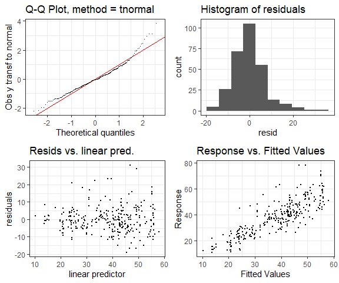

```r
b <- getViz(gam_mod)
check(b,
      a.qq = list(method = "tnorm",
                  a.cipoly = list(fill = "light blue")),
      a.respoi = list(size = 0.5),
      a.hist = list(bins = 10))
```

2.- ANÁLISIS DE CONCURVIDAD DEL MODELO GAM 1

Todos los valores son menores a 0.8, lo cual indica que no existen problemas de concurvidad.

```r
dt <- as.data.frame(concurvity(gam_mod))
dt %>%
  kbl() %>%
  kable_styling(full_width = FALSE)
```

|  | para | s(house_age) | s(dist_MRT_station) | s(numb_conv_stores) |
| --- | --- | --- | --- | --- |
| worst | 0 | 0.4082837 | 0.7284302 | 0.7077836 |
| observed | 0 | 0.2464436 | 0.6310954 | 0.6274407 |
| estimate | 0 | 0.2000821 | 0.3756628 | 0.5481099 |

3.- INSPECCIÓN DEL MODELO GAM 2

```
Method: GCV   Optimizer: magic
Smoothing parameter selection converged after 4 iterations.
The RMS GCV score gradient at convergence was 0.00030781 .
The Hessian was positive definite.
Model rank =  84 / 84

Basis dimension (k) checking results. Low p-value (k-index<1) may
indicate that k is too low, especially if edf is close to k'.

                         k'   edf k-index p-value
s(house_age)           9.00  2.63    1.12    0.99
s(longitude,latitude) 74.00 40.58    0.99    0.43
```

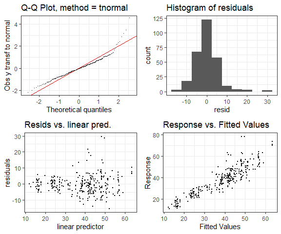

```r
b <- getViz(gam_mod_2)
check(b,
      a.qq = list(method = "tnorm",
                  a.cipoly = list(fill = "light blue")),
      a.respoi = list(size = 0.5),
      a.hist = list(bins = 10))
```

4.- ANÁLISIS DE CONCURVIDAD DEL MODELO GAM 2

Todos los valores son menores a 0.8, lo cual indica que no existen problemas de concurvidad.

```r
dt <- as.data.frame(concurvity(gam_mod_2))
dt %>%
  kbl() %>%
  kable_styling(full_width = FALSE)
```

|  | para | s(house_age) | s(longitude,latitude) |
| --- | --- | --- | --- |
| worst | 0 | 0.7585697 | 0.7585697 |
| observed | 0 | 0.5650527 | 0.1681300 |
| estimate | 0 | 0.5799306 | 0.0879862 |